# Proyecciones de un conjunto de modelos de nueva generación advierten mayores riesgos climáticos para los ecosistemas marinos

Derek P. Tittensor, Camilla Novaglio, Cheryl S. Harrison, Ryan F. Heneghan, *et al.

02/2021

- **NOTA: esta es una traducción al español del artículo:** *Next-generation ensemble projections reveal higher climate risks for marine ecosystems*, escrito por Derek P. Tittensor, Camilla Novaglio, Cheryl S. Harrison, Ryan F. Heneghan, *et al.*, y que se puede encontrar en la siguiente [liga](https://www.nature.com/articles/s41558-021-01173-9).
- **Forma de Citar**: Tittensor, D.P., Novaglio, C., Harrison, C.S., Heneghan, R.F., Barrier, N., Bianchi, D., Bopp, L., Bryndum-Buchholz, A., Britten, G.L., Büchner, M., Cheung, W.W.L., Christensen, V., Coll, M., Dunne, J.P., Eddy, T.D., Everett, J.D., Fernandes-Salvador, J.A., Fulton, E.A., Galbraith, E.D., Gascuel, D., Guiet, J., John, J.G., Link, J.S., Lotze, H.K., Maury, O., Ortega-Cisneros, K., Palacios-Abrantes, J., Petrik, C.M., du Pontavice, H., Rault, J., Richardson, A.J., Shannon, L., Shin, Y.-J., Steenbeek, J., Stock, C.A., Blanchard, J.L., 2021. Next-generation ensemble projections reveal higher climate risks for marine ecosystems. *Nat. Clim. Chang.*

*Traducido por Juliano Palacios. Revisión técnica de Guillermo Palacios.*

Descargar Artículo en Español

# Resumen

Las proyecciones de los impactos del cambio climático en los ecosistemas marinos han revelado una disminución a largo plazo en la biomasa global de animales marinos e impactos desiguales en las pesquerías mundiales. En el presente estudio se combina un conjunto mejorado de modelos de ecosistemas marinos globales del Proyecto de Intercomparación de Modelos de Ecosistemas Marinos y Pesqueros (Fish-MIP), con los modelos de nueva generación del sistema terrestre de la Fase 6 del Proyecto de Intercomparación de Modelos Acoplados (CMIP6), para realizar diversas proyecciones sobre cómo el cambio climático afectará los ecosistemas marinos futuros. En comparación con la combinación de la generación anterior de Fish-MIP-CMIP5, el nuevo conjunto de simulaciones de ecosistemas marinos muestra una mayor disminución en el promedio global de biomasa animal marina tanto en escenarios de fuerte mitigación como de altas emisiones debido al calentamiento elevado. En este último escenario, esto sucede a pesar de una mayor incertidumbre en la producción primaria neta. Los cambios regionales de dirección de los impactos a la biomasa destacan una necesidad continua y urgente de reducir la incertidumbre en las proyecciones de los ecosistemas marinos al cambio climático.

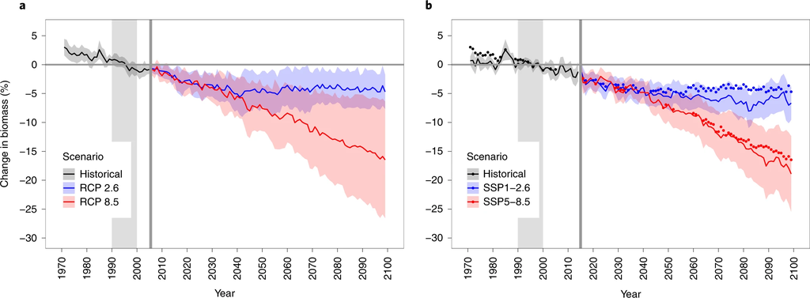

**Cambio promedio en la biomasa de animales marinos en escenarios de mitigación fuerte y altas emisiones. Promedio de todos los modelos utilizados. Figura 3 del artículo original**

# Texto principal

El cambio climático es una amenaza creciente para los ecosistemas marinos [1]. Sus impactos están proyectados a intensificar una serie de respuestas en los organismos marinos incluyendo un aumento en la mortalidad de individuos, una reducción en la calcificación de estructuras calcáreas y un cambio en la distribución, interacciones, abundancia y biomasa de distintas especies marinas [23]. Además, el cambio climático puede interactuar con otras fuentes de estrés como la pesca [45], que puede amenazar la conservación marina [6] y los beneficios sociales derivados de los recursos marinos [78]. Es por esto que es fundamental comprender los riesgos que el cambio climático trae para los ecosistemas marinos, así como los beneficios que la mitigación de dichos riesgos puede traer a los sistemas socio-ecológicos. Proyectar la magnitud y los impactos del cambio climático a través de proyectos de intercomparación de modelos (MIP, por sus siglas en inglés) produce un conjunto de proyecciones que permiten la cuantificación de la variabilidad entre modelos (por ejemplo, el rango de proyecciones de menor a mayor) [9] y estimulan esfuerzos a largo plazo para desarrollar y mejorar dichos modelos. El MIP más destacado, el Proyecto de Intercomparación de Modelos Acoplados (CMIP, por sus siglas en inglés) [10], se encuentra actualmente en su sexta fase de experimentos de simulación del modelo del sistema terrestre (ESM, por sus siglas en inglés) y es una contribución fundamental al sexto Informe de evaluación del Grupo Intergubernamental de Expertos sobre el Cambio Climático (IPCC AR6, por sus siglas en inglés). Los resultados de las simulaciones también se pueden utilizar para impulsar otros modelos para explorar cómo el cambio climático afectará a sectores humanos o procesos naturales específicos.

Si bien modelos de ecosistemas marinos (MEM, por sus siglas en inglés) han sido utilizados para explor los impactos del cambio climático en ecosistemas marinos de forma independiente, el Proyecto de Intercomparación de Modelos de Ecosistemas Marinos y Pesqueros (Fish-MIP, por sus siglas en inglés) compara los modelos producidos por diferentes grupos utilizando proyecciones estandarizadas [11]. Fish-MIP ha explorado una variedad de temas, incluidos los cambios globales [12] y regionales [131415] durante este siglo y sus posibles consecuencias socioeconómicas [8]. Todas las contribuciones de Fish-MIP hasta la fecha han sido impulsadas por los resultados de los ESMs del CMIP5. Sin embargo, la “próxima generación” de ESMs del CMIP6 proporcionan un conjunto actualizado de condiciones oceanográficas [16,17]. En este artículo, comparamos un conjunto de MEMs combinados con las versiones del CMIP5 y CMIP6 de los ESMs del Laboratorio de Dinámica de Fluidos Geofísicos (GFDL) y del Institut Pierre-Simon Laplace (IPSL). La simulación GFDL tiene una resolución espacial más alta en el CMIP6 que en el CMIP5. Los ESM del CMIP6 tienen mejor representación de la biogeoquímica marina [18], el hielo marino y otras propiedades oceanográficas. Así mismo, el sesgo de los modelos del CMIP6 se redujo en un 20-70% para el nitrato, fosfato y silicato de superficie en relación con los CMIP5, y el error cuadrático medio de la raíz para la temperatura de la superficie y la clorofila fue mejorado [17,18]. Finalmente, los modelos del CMIP6 exhiben una mayor sensibilidad climática (la respuesta de la temperatura media del aire en la superficie a un aumento en el CO2 atmosférico) que los del CMIP5 [19]. Esto resulta en efectos generalmente más fuertes en los ecosistemas marinos cuando se considera un escenario de altas emisiones (por ejemplo, calentamiento de los océanos). Cabe resaltar que existe una mayor variación en términos de impactos sobre la productividad primaria neta (NPP, por sus siglas en inglés) en dicho escenario [17,20].

Se han agregado tres nuevos MEM globales al conjunto Fish-MIP, con lo que el total asciende a nueve modelos ([Tabla 1](https://www.nature.com/articles/s41558-021-01173-9/tables/1)). En el siguiente artículo se presentan los resultados de dicho conjunto bajo los escenarios de altas y bajas emisiones del CMIP6. Se consideran las variables de temperatura y productividad primaria como impulsores clave del cambio en los ecosistemas marinos ya que estas variables son utilizadas por todos los MEMs ([Tabla complementaria 1](https://static-content.springer.com/esm/art%3A10.1038%2Fs41558-021-01173-9/MediaObjects/41558_2021_1173_MOESM1_ESM.pdf)). Así mismo, se utilizó un subconjunto de MEMs que fueron previamente combinados con los ESMs del CMIP5 y comparados con aquellos combinados con los CMIP6. Esto se hizo con el fin de evaluar las consecuencias ecosistémicas y los beneficios de mitigación relacionadas con las mejoras en los modelos climáticos (i.e., los ESMs). El protocolo de simulación de Fish-MIP para el CMIP6 se mantuvo lo más similar posible al protocolo del CMIP5 para permitir la comparación directa, incluido el uso de los mismos ESMs (aunque de diferentes generaciones) y centrándose en los impactos climáticos en la biomasa total de animales marinos.

# Simulaciones de los Modelos del Sistema Terrestre (ESMs)

Las simulaciones del CMPI6 para los dos ESMs muestran un mayor calentamiento global medio de la superficie del océano entre 1990 y 2090 bajo un escenario de altas emisiones, en comparación con las simulaciones del CMIP5 ([Fig. 1a, B](https://www.nature.com/articles/s41558-021-01173-9/figures/1)). Dicha diferencia es menor para el escenario de bajas emisiones. Por otro lado, existe una mayor variabilidad en los cambios proyectados en la NPP ([Fig. 1c, d](https://www.nature.com/articles/s41558-021-01173-9/figures/1)) y biomasa de plancton ([Fig. 1e-h](https://www.nature.com/articles/s41558-021-01173-9/figures/1)). En las simulaciones del CMIP5, únicamente el IPSL bajo altas emisiones muestra una disminución general en la NPP global, de ~ 10% para 2090-2099 ([Fig. 1c](https://www.nature.com/articles/s41558-021-01173-9/figures/1)). Todas las demás simulaciones (GFDL para ambos escenarios e IPSL para bajas emisiones) muestran pocos cambios globales en la NPP. Sin embargo, para ambos escenarios del CMIP6, el GFDL muestra una disminución de 5 a 10% en la NPP global mientras que el IPSL proyecta un aumento de la misma magnitud con respuestas más marcadas en el escenario de altas emisiones ([Fig. 1d](https://www.nature.com/articles/s41558-021-01173-9/figures/1)). El aumento en la NPP del IPSL-CMIP6 es especialmente prominente en los giros sub-tropicales ([Fig. 1](https://www.nature.com/articles/s41558-021-01173-9/figures/1)). Un análisis preliminar sugiere que esto podría estar relacionado con un aumento en la fijación de nitrógeno inducido por el calentamiento global [17]. Es importante destacar que, a pesar del aumento de la NPP, tanto la biomasa de fitoplancton como la de zooplancton sufren disminuciones marcadas para el IPSL-CMIP6. Dichas disminuciones coinciden con los resultados del CMIP5, aunque con mayores diferencias entre los dos ESMs ([Fig. 1e-h](https://www.nature.com/articles/s41558-021-01173-9/figures/1)). Tanto el IPSL como el GFDL del CMIP6 proyectan aumentos de la temperatura de la superficie del mar (SST, por si siglas en inglés) en casi todo el océano bajo el escenario de altas emisiones ([Fig. 2b](https://www.nature.com/articles/s41558-021-01173-9/figures/2)). Las regiones con los cambios más acentuados son el Ártico, las regiones templadas del norte (excepto el centro del Giro subpolar del Atlántico norte) y un cinturón alrededor del Ecuador.

Los océanos polares muestran un mayor calentamiento de la SST en las simulaciones del CMIP6 que en las del CMIP5 ([Fig. 2c](https://www.nature.com/articles/s41558-021-01173-9/figures/2) y [Figs. 1](https://www.nature.com/articles/s41558-021-01173-9/figures/1) y 2) así cono un aumento en la NPP a lo largo del siglo XXI, bajo el escenario de altas emisiones (Fig. 2e y datos extendidos, figuras 1 y 2). En grandes áreas del Pacífico y Atlántico norte, las proyecciones muestran una disminución de NPP ([Fig. 2e](https://www.nature.com/articles/s41558-021-01173-9/figures/2)), aunque la extensión continúa siendo menor que en los modelos del CMIP5 ([Fig. 2d, e](https://www.nature.com/articles/s41558-021-01173-9/figures/2)). El océano Ártico muestra un aumento general en la NPP en los modelos del CMIP6 frente a los del CMIP5, aparentemente impulsado por diferencias entre el IPSL-CMIP5 y IPSL-CMIP6 ([Figs. 1 y 2](https://www.nature.com/articles/s41558-021-01173-9/figures/2)). Los cambios negativos en la biomasa de fitoplancton y zooplancton son más pronunciados, disminuyendo en todas partes del océano excepto en los polos ([Fig. 2g-l](https://www.nature.com/articles/s41558-021-01173-9/figures/2)), y más variables regionalmente para el zooplancton (Fig. 2j-l). Sin embargo, la congruencia en la distribución espacial de los cambios negativos de biomasa de plancton entre el CMPI5 y CMIP5 fue mayor que para NPP [Fig. 2e, h, k](https://www.nature.com/articles/s41558-021-01173-9/figures/2).

# Simulaciones de los Modelos de Ecosistemas Marinos (MEM)

Las proyecciones de biomasa animal marina promedio del conjunto completo de MEMs no muestran una diferencia clara entre las simulaciones del CMIP5 y CMIP6 hasta ~ 2030 ([Fig. 3](https://www.nature.com/articles/s41558-021-01173-9/figures/3)). Después del 2030, los modelos del CMIP6 muestran una disminución más pronunciada en la biomasa animal. Dicha reducción sucede en casi todos los años bajo el escenario de fuerte mitigación y en la mayoría de los años a partir de 2060 en el de altas emisiones ([Fig. 3](https://www.nature.com/articles/s41558-021-01173-9/figures/3)).

La disminución global de biomasa es significativamente más pronunciada en 2090-2099 para ambos escenarios del CMIP6 que para los del CMIP5 (prueba de suma de rangos de *Wilcoxon* de dos lados en valores anuales; *n* = 160 para CMIP6, 120 para CMIP5; *W* = 12,290 y *P* <0.01 para mitigación fuerte, *W* = 11,221 y *P* = 0,016 para emisiones altas). Para el conjunto comparable de MEMs (i.e., el conjunto que fue corrido con el CMIP5 y CMIP6), únicamente el escenario de mitigación fuerte es significativamente diferente (*n* = 120 para ambos CMIPs; *W* = 6,623 y *P* <0.01; ([Fig. Extendida 3B](https://www.nature.com/articles/s41558-021-01173-9/figures/8)). Estos resultados parecen no deberse simplemente a la variabilidad temporal del conjunto de ESMs ya que existen varias décadas consecutivas en las que las proyecciones de CMIP6 son más negativas que las del CMIP5 ([Fig. 3b](https://www.nature.com/articles/s41558-021-01173-9/figures/3) y [Fig. Extendida 3B](https://www.nature.com/articles/s41558-021-01173-9/figures/8)). Bajo el escenario de altas emisiones, la biomasa media de animales marinos proyectada con el conjunto completo del MEM-CMIP6 disminuye en ~ 19% para 2099 en relación con 1990-1999 (~ 2.5% más que la del MEM-CMIP5). Ya para el escenario de fuerte mitigación, la biomasa disminuye en ~ 7% (~ 2% más que la del MEM-CMIP5). Se observaron disminuciones similares para el conjunto comparable de MEMs. En particular, las desviaciones estándar entre los modelos muestran una separación total entre los escenarios de altas emisiones y de fuerte mitigación del CMIP6 después de la década de 2080. Esto aplica tanto para el conjunto completo de MEMs como para el conjunto comparable ([Fig. 3](https://www.nature.com/articles/s41558-021-01173-9/figures/3)). Por otro lado, las desviaciones estándar entre los MEMs del CMIP5 se sobreponen, es decir, no muestran dicha separación. Esto se debe principalmente a una reducción de la desviación estándar entre modelos para el escenario de altas emisiones. Por ejemplo, todos los MEMs combinados con el GFDL-CMIP6 proyectan una mayor disminución en la biomasa animal para la segunda mitad del siglo XXI ([Fig.4c, d](https://www.nature.com/articles/s41558-021-01173-9/figures/4) y Datos extendidos Fig. 4c, d). Esto hace que las proyecciones de esos modelos (i.e., MEM-GFDL-CMIP6) sean similares a los modelos combinados con el IPSL.

A nivel global, los cambios de biomasa en ambos conjuntos de MEMs ( el completo y el comparable) muestran patrones espaciales similares entre el CMIP5 y el CMIP6 para ambos escenarios ([Fig. 5a](https://www.nature.com/articles/s41558-021-01173-9/figures/5) y Figs. [5a](https://www.nature.com/articles/s41558-021-01173-9/figures/5) y [6a, b](https://www.nature.com/articles/s41558-021-01173-9/figures/11)), sin embargo, existen diferencias sustanciales a nivel regional ([Figs. 5a-c](https://www.nature.com/articles/s41558-021-01173-9/figures/5) y [Figs. 5a-c](https://www.nature.com/articles/s41558-021-01173-9/figures/11) y [6a-c](https://www.nature.com/articles/s41558-021-01173-9/figures/12) de datos extendidos). Para ambos CMIP6-ESMs, los MEMs proyectan un aumento promedio en la biomasa animal en prácticamente todas las partes del Ártico para 2090. Ya para los CMIP5-ESMs, algunos MEMs proyectan aumentos en la región mientras que otros proyectan disminuciones en la biomasa promedio animal. El patrón espacial de cambio de biomasa animal es heterogéneo para otras regiones, aunque el ecuador muestra una disminución constante de la biomasa tanto para CMIP5 como para CMIP6 ([Figs. 5a-c](https://www.nature.com/articles/s41558-021-01173-9/figures/5) y [Figs. 11a-c](https://www.nature.com/articles/s41558-021-01173-9/figures/16) de los datos extendidos).

El conjunto de MEMs del CMIP5 y del CMIP6 muestran la misma dirección de cambio de biomasa animal en 71% de las celdas de la cuadrícula, con un 15% cambiando de disminución (CMIP5) para aumento (CMIP6) ([Fig. 5d](https://www.nature.com/articles/s41558-021-01173-9/figures/5)) y otro 14% viceversa ([Fig. 5e](https://www.nature.com/articles/s41558-021-01173-9/figures/5)). Entre las áreas que cambian entre el CMIP5 y el CMIP6, grandes partes del Océano Ártico muestran cambios positivos mientras que una gran área de latitudes templadas exhibe cambios negativos ([Figs. 5d-e](https://www.nature.com/articles/s41558-021-01173-9/figures/5)). Cabe resaltar que el porcentaje de similitud entre los MEMs es bastante alta (> 80%) en la mayoría de las regiones oceánicas del CMIP6 ([Fig.7e, f](https://www.nature.com/articles/s41558-021-01173-9/figures/12) de los datos extendidos). Las excepciones son los giros sub-tropicales donde los resultados coinciden en apenas 50% (“desacuerdo” máximo entre modelos), probablemente debido a las diferencias de la NPP del CMIP6 previamente señaladas y a las diversas formas en que los MEMs incorporan los efectos del cambio climático en los niveles tróficos inferiores. Independientemente de si se considera el grupo de MEMs completo o el comparable, no hay una clara mejora espacial en la “coincidencia” de los modelos en comparación con los del CMIP5 (figuras [8](https://www.nature.com/articles/s41558-021-01173-9/figures/13), [9](https://www.nature.com/articles/s41558-021-01173-9/figures/14) y [10](https://www.nature.com/articles/s41558-021-01173-9/figures/15) de los datos extendidos).

# Discusión y conclusiones

La comparación de los MEMs impulsados por el GFDL e IPSL del CMIP5 y del CMIP6 reveló una reorganización espacial de los cambios en la biomasa animal marina proyectada debido al cambio climático. En promedio, la biomasa de animales marinos está proyectada para disminuir en mayor intensidad bajo los resultados de los ESMs-CMIP6 que los ESMs-CMIP5 ([Fig. 3](https://www.nature.com/articles/s41558-021-01173-9/figures/3)) además de presentar una mayor diferencia entre los escenarios de altas emisiones y de fuerte mitigación ([Fig. 3](https://www.nature.com/articles/s41558-021-01173-9/figures/3), and [Fig. 3B](https://www.nature.com/articles/s41558-021-01173-9/figures/8) de los datos extendidos). La diferencia parece deberse principalmente a una mayor sensibilidad climática de las simulaciones del CMIP6, específicamente las simulaciones del IPSL y el GFDL. Esto está respaldado por los resultados del conjunto comparable de MEMs (datos extendidos, figuras 3-5 y 8).

El calentamiento del agua puede afectar diferentes mecanismos de los MEMs como el metabolismo de individuos, las tasas de producción de biomasa y de mortalidad, la distribución de las especies, así como las interacciones inter-específicas. Un estudio detallado de la respuesta de los MEMs al calentamiento del agua en forma aislada [21] reveló una variabilidad sustancial en los mecanismos y las respuestas de los MEMs. Sin embargo, todos los MEMs mostraron un impacto negativo en la biomasa marina global. El calentamiento global también va acompañado de una mayor estratificación de los océanos y una disminución marcada en la biomasa de fitoplancton no fijador de nitratos [23]. La combinación de estos efectos revela una disminución constante de la biomasa animal global tanto en CMIP5 como en CMIP6, con una disminución mas intensa en CMIP6.

De modo general, los ESMs mostraron tendencias similares de NPP en respuesta al calentamiento global [24], sin embargo, las diferencias en los patrones regionales y su firma global continuan siendo un problema [25]. Estrategias para mejorar el reciclaje y la NPP, a pesar de la creciente estratificación de la superficie del océano, incluyen la incorporación de procesos de remineralización dependientes de la temperatura. No obstante, dichos procesos son tratados de manera desigual en todos los ESMs. Los regímenes limitados por la absorción de nutrientes y captación de luz solar de los modelos bio-geo-químicos pueden verse afectados latitudinalmente debido a la incertidumbre de las variaciones de dichos parámetros. Es probable que la absorción de nutrientes se vea afectada positivamente mientras que la captación de luz lo sea negativamente debido al aumento de la estratificación del agua bajo el cambio climático [26]. Los cambios regionales de circulación, que a menudo varían mucho entre ESMs, pueden moldear las tendencias regionales de NPP [27]. Actualmente existen esfuerzos para restringir los factores que controlan la respuesta de la NPP al cambio climático [28] o aprovechar las restricciones emergentes para reducir la incertidumbre de las proyecciones de NPP [23], pero éstos no dieron como resultado una convergencia entre modelos del CMIP6. Así mismo, cabe resaltar que ningún MEMs incluye aún el potencial de adaptación o evolución de taxones individuales y que éstos siguen sin tener un acoplamiento bi-direccional completo entre los niveles tróficos superior e inferior (procesos bio-geo-químicos). Finalmente, muchas interacciones de especies no son bien capturadas por los MEMs a escala global, y el potencial de puntos de inflexión no lineales que causan un rápido deterioro ecológico siguen sin estar claros [21].

El presente estudio explora las incertidumbres en las proyecciones de biomasa animal a través de un conjunto de modelos ecosistémicos marinos (MEMs) combinados con dos ESMs contrastantes y dos escenarios de cambio climático. Si bien el objetivo fue utilizar los mismos dos ESMs que fueron utilizados en los experimentos del CMIP5 [11,12], la adición de más ESMs al conjunto podrá reducir la incertidumbre asociada a los diferentes modelos del sistema Terrestre. Por otro lado, el tratamiento de la incertidumbre asociada con la variabilidad climática interna en el presente estudio es limitado. De manera general, para la mayoría de los impulsores bio-geo-químicos relevantes para la pesca [30,31], a escalas de tiempo de varias décadas a un siglo, la variabilidad climática interna es una fuente menor de incertidumbre a comparación con aquella generada por distintos modelos y/o escenarios de cambio climático. No obstante, es importante que esfuerzos futuros se centren en caracterizar de manera más completa la incertidumbre asociada a la variabilidad climática interna con el objetivo de presentar resultados con una menor fuente de incertidumbre. La sensibilidad a las respuestas climáticas en los MEMs también podría examinarse mediante una serie de variables ecológicas y/o bio-geo-químicas modeladas y observadas en el pasado. Dichas variables podrían limitar las respuestas al cambio climático (llamadas restricciones emergentes [23]), mejorando potencialmente ambos conjuntos de modelos. Además, la inclusión de otros componentes bio-geo-químicos (como el oxígeno) en más MEMs ([Tabla complementaria 1](https://static-content.springer.com/esm/art%3A10.1038%2Fs41558-021-01173-9/MediaObjects/41558_2021_1173_MOESM1_ESM.pdf)) permitiría una exploración conjunta de una mayor variedad de impactos climáticos. Esto será posible mediante el creciente desarrollo de los MEMs y la comunicación entre las comunidades que desatollan modelos de proyección de cambio climático y las que estudian los impactos de dichas proyecciones, como a través de la *CMIP6 Vulnerability, Impacts, Adaptation and Climate Services Advisory Board* [16].

Es muy importante destacar que los resultados de los MEMs explorados aquí se centran en la biomasa animal total y no incluyen los impactos de la pesca, los cuales pueden actuar de forma sinérgica con el cambio climático [4]. En consecuencia, incorporar la actividad pesquera en los modelos podría resultar en cambios mayores de biomasa animal. Si bien restaurar las poblaciones sobre-explotadas y limitar el esfuerzo pesquero a niveles sustentables puede ayudar con la adaptación al cambio climático a nivel regional y mundial [32], los resultados del CMIP6 sugieren que hay mayores desafíos por delante para el potencial pesquero de lo que se había anticipado anteriormente. El potencial de producción pesquera se ha mantenido prácticamente sin cambios durante los últimos 40 años a pesar del aumento del esfuerzo pesquero, con desembarques de la pesca de captura marina del orden de 0,1 $Gtyr^{–1}$ (ref. 33). Si las proyecciones del CMIP6 se mantienen, la contribución de la pesca de animales marinos a la seguridad alimentaria mundial puede verse aún más cuestionada. Al igual que estudios anteriores de Fish-MIP [8,12], los resultados aquí presentados se centran en la biomasa total (potencial) del ecosistema, en lugar de la biomasa “comestible” disponible para la pesca. Esto es, en parte, porque el objetivo fue estudiar la respuesta general del ecosistema al cambio climático ambiental. Además, dada la naturaleza heterogénea de los MEMs, sólo una proporción de éstos trabaja a nivel de especie, por lo que la biomasa total del ecosistema es una variable que se puede comparar entre modelos. Los resultados del conjunto que se presentan aquí complementan estudios organizacionales [34] y espaciales [35] de los impactos y las vulnerabilidades del cambio climático, tanto para el desarrollo de MEMs individuales, así como para proporcionar proyecciones a nivel de ecosistema de tendencias e incertidumbres debido a cambios en la temperatura y productividad. Dichos resultados proporcionan un contexto adicional a los estudios de menor escala que exploran nichos térmicos y las respuestas de la historia de vida de las especies a factores ambientales. Para proyecciones robustas de biomasa de peces comestibles sería necesario tener información adicional que aún no está disponible (ni incluida en las Rutas Socioeconómicas Compartidas (SSP)), como son escenarios económicos futuros, de comportamiento de flota pesquera y de cambios en las especies objetivo-pescadas. La disminución proyectada de biomasa animal global no significa, necesariamente, que las capturas pesqueras mundiales se reduzcan en la misma proporción; los cambios en la producción animal, cuando se exploraron en MEMs individuales, sugieren una respuesta climática similar a la biomasa, aunque de menor magnitud [36,37]. Sin embargo, los autores reconocen que la pesca puede actuar de manera sinérgica con el cambio climático [4] y que su incorporación sigue siendo una preocupación importante, razón que explica que Fish-MIP esté en proceso de desarrollar escenarios para permitir tales comparaciones.

Las proyecciones de los dos ESMs-CMIP6 de los impactos del cambio climático en el siglo XXI muestran una mayor disminución en la biomasa global y, por lo tanto, mayores riesgos climáticos para los ecosistemas marinos que sus contrapartes del CMIP5 al tiempo que enfatizan los beneficios de una fuerte mitigación. Las diferencias marcadas en la dirección de los resultados para muchas regiones del océano global, probablemente impulsados por diferencias en los ESMs (en particular la NPP), resaltan las grandes incertidumbres que aún existen. Esto sugiere que los MEMs combinados con ESMs a escala global aún son poco eficientes para apoyar políticas publicas de adaptación a nivel nacional, aunque es posible que MEMs regionales sean más eficientes [38].

Sigue existiendo una necesidad urgente de perfeccionar el modelo para abordar la incertidumbre en todos los niveles, incluidas las proyecciones climáticas y de ecosistemas marinos. Sólo una vez que se hayan abordado estas incertidumbres, de modo que se mejore la relación entre los modelos ecosistémicos y climáticos, las proyecciones de los impactos climáticos sobre los organismos marinos y las pesquerías serán más sólidas y, por lo tanto, más útiles estratégicamente. Se requiere una evaluación de modelo más ambiciosa de todo el océano, incluidos los sistemas socio-ecológicos, para entregar las proyecciones rigurosas que se necesitan con urgencia para avanzar en la adaptación y mitigación climáticas.

# Métodos

Descripciones de los MEMs utilizados en las inter-comparaciones de Fish-MIP, sus estructuras y las variables de los ESMs empleadas pueden ser consultados en la ref. 11. En términos generales, las proyecciones de variables oceanográficas físicas y biogeoquímicas generadas por los ESMs a una escala de tiempo mensual son incorporadas bajo escenarios prescritos de cambio climático e interpoladas a una cuadrícula regular de $1^o$. Posteriormente, dichas variables se combinan con cada uno de los MEMs siguiendo el protocolo de simulación de Fish-MIP. En esta etapa cada MEM usa las variables relevantes para su modelo ([Tabla complementaria 1](https://static-content.springer.com/esm/art%3A10.1038%2Fs41558-021-01173-9/MediaObjects/41558_2021_1173_MOESM1_ESM.pdf)). Los resultados de cada MEM se archivan en un formato cuadriculado de $1^o$ estandarizado para un rango común de variables ecosistémicas.

En la ronda de simulación Fish-MIP empleada en este estudio se utilizaron dos ESMs: GFDL-ESM2M [51,52] e IPSL-CM5A-LR [53] para CMIP5 y las nuevas generaciones equivalentes para CMIP6, GFDL- ESM4.1 [54,55,56] e IPSL-CM6A-LR [57,58,59]. Esto se hizo con el objetivo de permitir la mejor comparación posible entre el CMIP5 y el CMIP6. Dichos ESMs fueron elegidos originalmente a partir de una serie de criterios incluyendo el hecho de que abarcaban una fracción sustancial del rango de variables oceanográficas proyectadas por todos los ESMs del CMIP5 [11]. Las proyecciones fueron comparadas bajo los escenarios de cambio climático, RCP 2.6 (CMIP6 SSP1–2.6) de mitigación fuerte y RCP 8.5 (CMIP6 SSP5–8.5) de altas emisiones. Para los modelos de Fish-MIP combinados con el CMIP5, las simulaciones históricas abarcaron 1970–2005, y los escenarios RCP abarcaron 2006–2099; para el CMIP6, las simulaciones históricas abarcaron de 1970 a 2014 y los escenarios del SSP abarcaron de 2015 a 2099. Para permitir una comparación estandarizada entre CMIPs, se utilizó un período de referencia histórico de 1990–1999, con cambios en los productos del MEM evaluados en relación con este período.

El cambio climático fue considerado como el único factor de estrés impuesto a los ecosistemas marinos, sin la pesca u otras presiones antropogénicas superpuestas. Esto se hizo con el objetivo de permitir una comparación aún más directa entre el CMIP5 y el CMIP6, así como un aislamiento de los impactos climáticos. La principal variable de salida examinada (i.e., resultado de los MEMs) fue la biomasa total de animales marinos a nivel global, de acuerdo a los animales marinos de cada MEM (por ejemplo, especies o grupos funcionales) [11] que generalmente incluye los principales grupos taxonómicos o los principales taxones de peces ([Tabla 1](https://www.nature.com/articles/s41558-021-01173-9/tables/1)). Dado esto, se examinó la biomasa animal para cada modelo durante el siglo XXI en términos de cambio relativo, en lugar de valores absolutos. Para obtener detalles sobre la calibración y validación de cada modelo, consulte la ref. 12; para consultar los documentos de referencia clave de los MEMs, consulte la Tabla 1. El protocolo Fish-MIP actualizado completo para el CMIP6 se puede encontrar en https://bit.ly/3jhWH7c.

Además de los ESMs del CMIP6 de la nueva generación, dos de los seis MEMs globales del conjunto original de Fish-MIP también experimentaron mejoras. Esto refleja un mayor desarrollo de parametrización, procesos adicionales e hipótesis subyacentes para la estructura y la dinámica de los ecosistemas marinos (Tabla 1). Además, se agregaron tres MEMs adicionales al conjunto (EcoTroph [37,47], FEISTY[48] y ZooMSS[50]; Tabla 1). EcoTroph es un modelo basado en niveles tróficos que incluye todas las especies marinas de vertebrados e invertebrados; FEISTY es un modelo compuesto que incluye especies de peces pelágicos y demersales, así como invertebrados bénticos; ZooMSS es un modelo compuesto que incluye peces pero también se enfoca en resolver taxones de zooplancton. Además de examinar las proyecciones en todo el conjunto ampliado de MEMs-CMIP6 (“conjunto completo de MEMs”, *n* = 9), se realizó una comparación estandarizada más directa a partir de los resultados del conjunto de los seis MEMs previamente combinados con el CMIP5 (‘conjunto MEM comparable’). Una gran cantidad de MEMs regionales también contribuyen a Fish-MIP y justifican una investigación detallada a escala local, pero no se informan aquí para una comparación lo más directa posible.

# Referencias

1. IPCC Special Report on the Ocean and Cryosphere in a Changing Climate (eds Pörtner, H.-O. et al.) (IPCC, 2019).
2. Doney, S. C. et al. Climate change impacts on marine ecosystems. Ann. Rev. Mar. Sci. 4, 11–37 (2012).
3. Bindoff, N. L. et al. in Special Report on the Ocean and Cryosphere in a Changing Climate (eds Pörtner, H.-O. et al.) Ch. 5 (IPCC, 2019).
4. Griffith, G. P., Fulton, E. A., Gorton, R. & Richardson, A. J. Predicting interactions among fishing, ocean warming, and ocean acidification in a marine system with whole-ecosystem models. Conserv. Biol. 26, 1145–1152 (2012).
5. Fu, C. et al. Risky business: the combined effects of fishing and changes in primary productivity on fish communities. Ecol. Modell. 368, 265–276 (2018).
6. Tittensor, D. P. et al. Integrating climate adaptation and biodiversity conservation in the global ocean. Sci. Adv. https://doi.org/10.1126/sciadv. aay9969 (2019).
7. IPBES: Summary for Policymakers. In Global Assessment Report on Biodiversity and Ecosystem Services (eds Díaz, S. et al.) (IPBES Secretariat, 2019).
8. Boyce, D. G., Lotze, H. K., Tittensor, D. P., Carozza, D. A. & Worm, B. Future ocean biomass losses may widen socioeconomic equity gaps. Nat. Commun. 11, 2235 (2020).
9. Payne, M. R. et al. Uncertainties in projecting climate-change impacts in marine ecosystems. ICES J. Mar. Sci. 73, 1272–1282 (2016).
10. Eyring, V. et al. Overview of the Coupled Model Intercomparison Project Phase 6 (CMIP6) experimental design and organization. Geosci. Model Dev. 9, 1937–1958 (2016).
11. Tittensor, D. P. et al. A protocol for the intercomparison of marine fishery and ecosystem models: Fish-MIP v1.0. Geosci. Model Dev. 11, 1421–1442 (2018).
12. Lotze, H. K. et al. Global ensemble projections reveal trophic amplification of ocean biomass declines with climate change. Proc. Natl Acad. Sci. USA 116, 12907–12912 (2019).
13. Bryndum-Buchholz, A. et al. Twenty-first-century climate change impacts on marine animal biomass and ecosystem structure across ocean basins. Glob. Change Biol. 25, 459–472 (2019).
14. Bryndum-Buchholz, A. et al. Differing marine animal biomass shifts under 21st century climate change between Canada’s three oceans. Facets 5, 105–122 (2020).
15. Bryndum-Buchholz, A. et al. Climate-change impacts and fisheries management challenges in the North Atlantic Ocean. Mar. Ecol. Prog. Ser. 648, 1–17 (2020).
16. Ruane, A. C. et al. The vulnerability, impacts, adaptation and climate services advisory board (VIACS AB v1.0) contribution to CMIP6. Geosci. Model Dev. 9, 3493–3515 (2016).
17. Kwiatkowski, L. et al. Twenty-first century ocean warming, acidification, deoxygenation, and upper-ocean nutrient and primary production decline from CMIP6 model projections. Biogeosciences 17, 3439–3470 (2020).
18. Séférian, R. et al. Tracking improvement in simulated marine biogeochemistry between CMIP5 and CMIP6. Curr. Clim. Change Rep. 6, 95–119 (2020).
19. Meehl, G. A. et al. Context for interpreting equilibrium climate sensitivity and transient climate response from the CMIP6 Earth system models. Sci. Adv. 6, eaba1981 (2020).
20. Tebaldi, C. et al. Climate model projections from the Scenario Model Intercomparison Project (ScenarioMIP) of CMIP6. Earth Syst. Dyn. 12, 253–293 (2021).
21. Heneghan, R. F. et al. Disentangling diverse responses to climate change among global marine ecosystem models. Prog. Oceanogr. 198, 102659 (2021).
22. Zelinka, M. D. et al. Causes of higher climate sensitivity in CMIP6 models. Geophys. Res. Lett. 47, e2019GL085782 (2020).
23. Kwiatkowski, L. et al. Emergent constraints on projections of declining primary production in the tropical oceans. Nat. Clim. Change 7, 355–358 (2017).
24. Cabré, A., Marinov, I. & Leung, S. Consistent global responses of marine ecosystems to future climate change across the IPCC AR5 Earth system models. Clim. Dyn. 45, 1253–1280 (2015).
25. Laufkötter, C. et al. Drivers and uncertainties of future global marine primary production in marine ecosystem models. Biogeosciences 12, 6955–6984 (2015).
26. Doney, S. C. Plankton in a warmer world. Nature 444, 695–696 (2006).
27. Rykaczewski, R. R. & Dunne, J. P. Enhanced nutrient supply to the California Current Ecosystem with global warming and increased stratification in an Earth system model. Geophys. Res. Lett. 37, L21606 (2010).
28. Laufkötter, C., John, J. G., Stock, C. A. & Dunne, J. P. Temperature and oxygen dependence of the remineralization of organic matter. Glob. Biogeochem. Cycles 31, 1038–1050 (2017).
29. Coll, M. et al. Advancing global ecological modeling capabilities to simulate future trajectories of change in marine ecosystems. Front. Mar. Sci. 7, 741 (2020).
30. Hawkins, E. & Sutton, R. The potential to narrow uncertainty in regional climate predictions. Bull. Am. Meteorol. Soc. 90, 1095–1107 (2009).
31. Frölicher, T. L., Rodgers, K. B., Stock, C. A. & Cheung, W. W. L. Sources of uncertainties in 21st century projections of potential ocean ecosystem stressors. Glob. Biogeochem. Cycles 30, 1224–1243 (2016).
32. Gaines, S. D. et al. Improved fisheries management could offset many negative effects of climate change. Sci. Adv. 4, eaao1378 (2018).
33. The State of World Fisheries and Aquaculture 2020 (FAO, 2020).
34. Dahlke, F. T., Wohlrab, S., Butzin, M. & Pörtner, H.-O. Thermal bottlenecks in the life cycle define climate vulnerability of fish. Science 369, 65–70 (2020).
35. Stuart-Smith, R. D., Edgar, G. J. & Bates, A. E. Thermal limits to the geographic distributions of shallow-water marine species. Nat. Ecol. Evol. 1, 1846–1852 (2017).
36. Carozza, D. A., Bianchi, D. & Galbraith, E. D. Metabolic impacts of climate change on marine ecosystems: implications for fish communities and fisheries. Glob. Ecol. Biogeogr. 28, 158–169 (2019).
37. du Pontavice, H., Gascuel, D., Reygondeau, G., Stock, C. & Cheung, W. W. L. Climate-induced decrease in biomass flow in marine food webs may severely affect predators and ecosystem production. Glob. Change Biol. 27, 2608–2622 (2021).
38. Piroddi, C. et al. Effects of nutrient management scenarios on marine food webs: a pan-European assessment in support of the marine strategy framework directive. Front. Mar. Sci. 8, 179 (2021).
39. Maury, O. An overview of APECOSM, a spatialized mass balanced ‘Apex Predators ECOSystem Model’ to study physiologically structured tuna population dynamics in their ecosystem. Prog. Oceanogr. 84, 113–117 (2010).
40. Maury, O. & Poggiale, J. C. From individuals to populations to communities: a dynamic energy budget model of marine ecosystem size-spectrum including life history diversity. J. Theor. Biol. 324, 52–71 (2013).
41. Carozza, D. A., Bianchi, D. & Galbraith, E. D. The ecological module of BOATS-1.0: a bioenergetically-constrained model of marine upper trophic levels suitable for studies of fisheries and ocean biogeochemistry. Geosci. Model Dev. 9, 1545–1565 (2016).
42. Carozza, D. A. et al. Formulation, general features and global calibration of a bioenergetically-constrained fishery model. PLoS ONE 12, e0169763 (2017).
43. Cheung, W. W. L. et al. Building confidence in projections of the responses of living marine resources to climate change. ICES J. Mar. Sci. https://doi. org/10.1093/icesjms/fsv250 (2016).
44. Cheung, W. W. L., Dunne, J., Sarmiento, J. L. & Pauly, D. Integrating ecophysiology and plankton dynamics into projected maximum fisheries catch potential under climate change in the Northeast Atlantic. ICES J. Mar. Sci. 68, 1008–1018 (2011).
45. Blanchard, J. L. et al. Potential consequences of climate change for primary production and fish production in large marine ecosystems. Phil. Trans. R. Soc. B 367, 2979–2989 (2012).
46. Christensen, V. et al. The global ocean is an ecosystem: simulating marine life and fisheries. Glob. Ecol. Biogeogr. 24, 507–517 (2015).
47. Gascuel, D., Guénette, S. & Pauly, D. The trophic-level-based ecosystem modelling approach: theoretical overview and practical uses. ICES J. Mar. Sci. 68, 1403–1416 (2011).
48. Petrik, C. M., Stock, C. A., Andersen, K. H., van Denderen, P. D. & Watson, J. R. Bottom-up drivers of global patterns of demersal, forage, and pelagic fishes. Prog. Oceanogr. 176, 102124 (2019).
49. Jennings, S. & Collingridge, K. Predicting consumer biomass, size-structure, production, catch potential, responses to fishing and associated uncertainties in the world’s marine ecosystems. PLoS ONE 10, e0133794 (2015).
50. Heneghan, R. F. et al. A functional size-spectrum model of the global marine ecosystem that resolves zooplankton composition. Ecol. Modell. 435, 109265 (2020).